# Trump’s twitter tells us the other side of his speeches

# step4: Deepenig exploration of twitter

Surveys conducted by David Robinson confirmed us that the twitter sent out through Android actually has a bigger probabilities from himself rather than his teams.

```r
load(url("http://varianceexplained.org/files/trump_tweets_df.rda"))
head(trump_tweets_df)
```

```
## # A tibble: 6 × 16
##                                                                          text
##                                                                         <chr>
## 1         My economic policy speech will be carried live at 12:15 P.M. Enjoy!
## 2 Join me in Fayetteville, North Carolina tomorrow evening at 6pm. Tickets no
## 3            #ICYMI: "Will Media Apologize to Trump?" https://t.co/ia7rKBmioA
## 4 Michael Morell, the lightweight former Acting Director of C.I.A., and a man
## 5 The media is going crazy. They totally distort so many things on purpose. C
## 6 I see where Mayor Stephanie Rawlings-Blake of Baltimore is pushing Crooked
## # ... with 15 more variables: favorited <lgl>, favoriteCount <dbl>,
## #   replyToSN <chr>, created <dttm>, truncated <lgl>, replyToSID <lgl>,
## #   id <chr>, replyToUID <chr>, statusSource <chr>, screenName <chr>,
## #   retweetCount <dbl>, isRetweet <lgl>, retweeted <lgl>, longitude <chr>,
## #   latitude <chr>
```

```r
tweets <- trump_tweets_df %>%
select(id, statusSource, text, created) %>%
extract(statusSource, "source", "Twitter for (.*?)<") %>%
filter(source %in% c("Android"))
```

Let us look at the emotion code distribution of Trump’s nomination speeces:

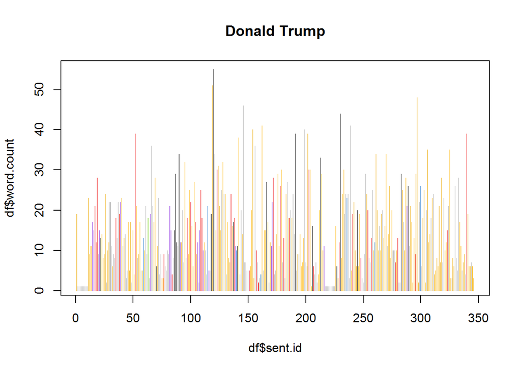

```r
f.plotsent.len(In.list=sentence.list, InFile="DonaldJTrump",
               InType="nomin", InTerm=1, President="Donald Trump")
```

We can find that some code colors appear on the image. So, let’s look at these “cold colors” more closely through twitter statistics.

```r
reg <- "([^A-Za-z\\d#@']|'(?![A-Za-z\\d#@]))"
tweet_words <- tweets %>%
  filter(!str_detect(text, '^"')) %>%
  mutate(text = str_replace_all(text, "https://t.co/[A-Za-z\\d]+|&", "")) %>%
  unnest_tokens(word, text, token = "regex", pattern = reg) %>%
  filter(!word %in% stop_words$word,
         str_detect(word, "[a-z]"))
wordFreq <- sort(table(tolower(tweet_words$word)),decreasing = TRUE)
wordFreq[1:30]
```

```
##
##     hillary     crooked     clinton      people        cruz         bad
##         124          93          66          64          50          43
##         ted      bernie         win   president       trump     america
##          41          40          35          31          31          30
##       media     totally        @cnn        jobs  republican        time
##          30          30          27          27          27          26
##     country     sanders        vote         job       obama       total
##          25          23          23          22          20          20
##         wow    @foxnews        beat       enjoy  convention interviewed
##          20          19          19          19          18          17
```

Top mentioned words seem to be agreessive and tough. And that may be the reason why so many US residence still against him till now.

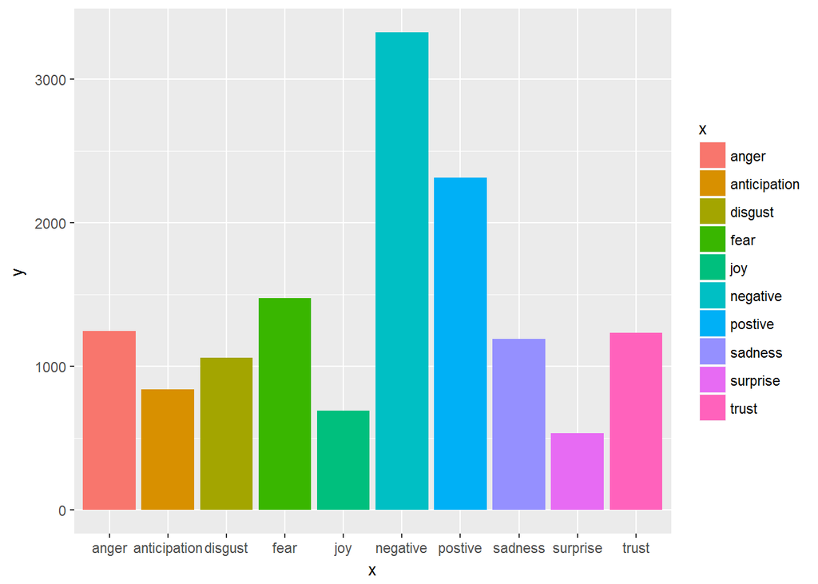

```r
nrc <- sentiments %>%
  filter(lexicon == "nrc") %>%
  dplyr::select(word, sentiment)
count<-rep(1,nrow(nrc))
nrc<-data.frame(nrc,count)
percent<-tapply(nrc$count,nrc$sentiment,sum)

x <- c('anger','anticipation','disgust','fear','joy','negative','postive','sadness','surprise','trust')
y <- percent
df <- data.frame(x= x, y = y)
ggplot(data = df, mapping = aes(x = x, y = y,fill=x)) + geom_bar(stat= 'identity')
```